# Uncertainty Propagation

Philip Dixon

10 November 2017

## Goal, in pictures:

Have spatial data on Soil OC and Soil N. Some locations have both; other locations have one or the other. Kriging gives you spatial predictions of OC and N, with location-specific uncertainties.

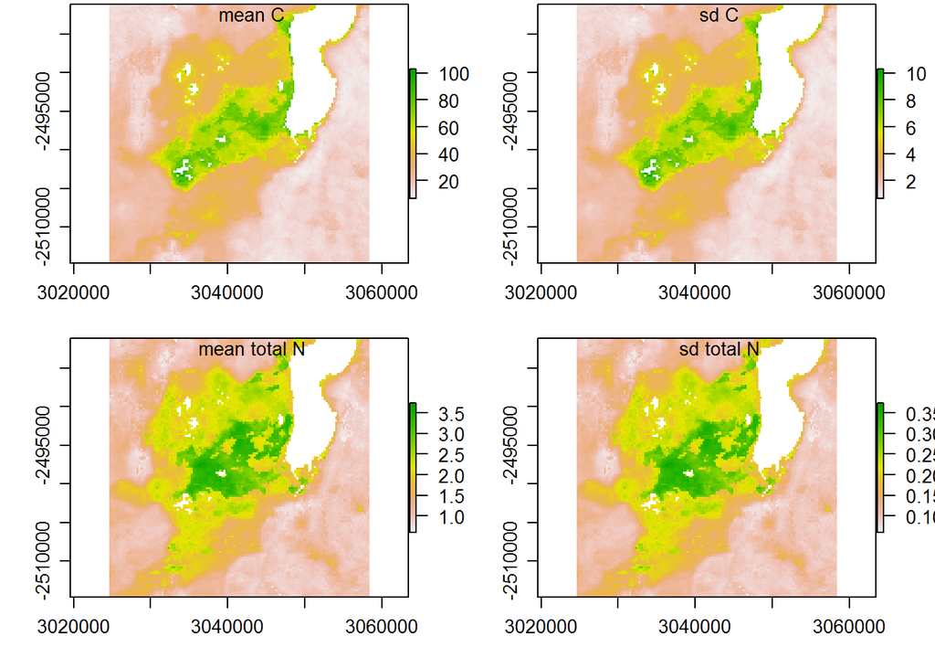

```r
library(spup)    # key package: SPatial Uncertainty Propagation
library(raster)  # raster graphics
library(purrr)   # library with similar functionality to dplyr

data(OC, OC_sd, TN, TN_sd)
par(mfrow=c(2,2), mar=c(3,3,0,0)+0.2, mgp=c(2,0.8,0))
plot(OC); legend('top', bty='n', legend='mean C', inset=-0.05)
plot(OC_sd); legend('top', bty='n', legend='sd C', inset=-0.05)
plot(TN); legend('top', bty='n', legend='mean total N', inset=-0.05)
plot(TN_sd); legend('top', bty='n', legend='sd total N', inset=-0.05)
```

You want a derived quantity: e.g., C/N ratio with its uncertainty. Would like to see this information two ways: 1) maps of C/N and 2) estimated area with C/N > 20. Want uncertainty for each (se or quantiles of the distribution).

Map of C/N is easy from the raster images. Operations on rasters produce rasters.

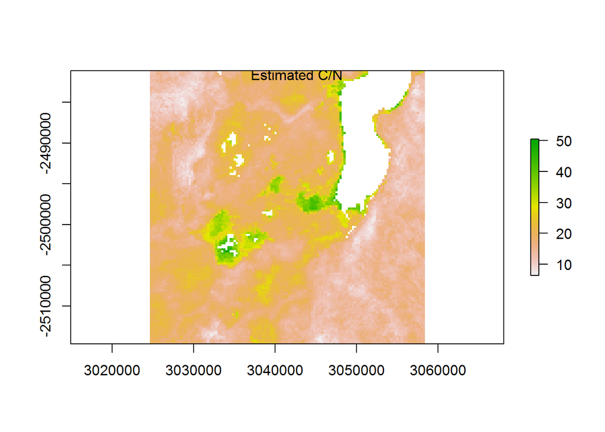

```r
CN <- OC/TN
par(mfrow=c(1,1))
plot(CN); legend('top', bty='n', legend='Estimated C/N', inset=-0.05)
```

But what is the uncertainty? Complicated here because

- quantity is a non-linear function of data
- OC and TN values are each spatially correlated
- OC and TN are cross-correlated (i.e, at same location)

spup library provides uncertainty distributions quantiles and summaries, like sd of estimates. Uses Monte-Carlo simulation.